# Projet-3 : Concevez une application au service de la santé publique

[figure not shown]

# Projet-3 : Concevez une application au service de la santé publique

## Introduction

- **Source des données** : Open Food Facts répertorie les informations sur les produits alimentaires : ingrédients, informations nutritionnelles, labels etc.
  - Les données proviennent majoritairement de la collecte citoyenne (crowdsourcing) des informations.
- **Utilisation de la base** :
  - Traiter le jeu de données afin de repérer des variables pertinentes pour les traitements à venir. Automatiser ces traitements pour éviter de répéter ces opérations.
  - **Idée de l'application** : aide à l'identification des produits à surveiller dans le cas de régime alimentaire liées à la surveillance en utilisant la base d'OpenFood Facts

## Environnement

```python
import pandas as pd
import numpy as np
import datetime as dt
import sys
import warnings
import IPython as ip
import matplotlib.pyplot as plt
import seaborn as sns
from IPython.display import display
import missingno as msno
# Configuration pour travail avec fichier python "tools" de fonctions
%load_ext autoreload
%aimport tools

# Set option
pd.set_option('display.max_columns', None)
pd.set_option('display.max_rows', None)

# Recharger les modules pour la conception des fichiers tools

%autoreload 1

warnings.filterwarnings("ignore")
```

# 1. Chargement des données

```python
# Import données
data = pd.read_csv('assets/datas/openfoodfacts.csv', sep='\t', low_memory=False)
```

# 2. Nettoyage du jeu de données

```python
# Afficher le nombre de lignes de colonnes et de doublon je de données initial
tools.get_info_data(data,doublon=True)
```

```
------------------------------------------------------------------
Taille du jeu de données

Nombre de lignes : 320772 lignes
Nombre de colonnes : 162 colonnes
Nombre d'éléments dupliqués dans le dataframe : 0 eléments
------------------------------------------------------------------
```

```python
# Afficher les 3 premières lignes du jeu de données
data.head(3)
```

|  | code | url | creator | created_t | created_datetime | last_modified_t | last_modified_datetime | product_name | generic_name | quantity | packaging | packaging_tags | brands | brands_tags | categories | categories_tags | categories_fr | origins | origins_tags | manufacturing_places | manufacturing_places_tags | labels | labels_tags | labels_fr | emb_codes | emb_codes_tags | first_packaging_code_geo | cities | cities_tags | … |
| --- | --- | --- | --- | --- | --- | --- | --- | --- | --- | --- | --- | --- | --- | --- | --- | --- | --- | --- | --- | --- | --- | --- | --- | --- | --- | --- | --- | --- | --- | --- |
| 0 | 0000000003087 | http://world-fr.openfoodfacts.org/produit/0000... | openfoodfacts-contributors | 1474103866 | 2016-09-17T09:17:46Z | 1474103893 | 2016-09-17T09:18:13Z | Farine de blé noir | NaN | 1kg | NaN | NaN | Ferme t'y R'nao | ferme-t-y-r-nao | NaN | NaN | NaN | NaN | NaN | NaN | NaN | NaN | NaN | NaN | NaN | NaN | NaN | NaN | NaN | … |
| 1 | 0000000004530 | http://world-fr.openfoodfacts.org/produit/0000... | usda-ndb-import | 1489069957 | 2017-03-09T14:32:37Z | 1489069957 | 2017-03-09T14:32:37Z | Banana Chips Sweetened (Whole) | NaN | NaN | NaN | NaN | NaN | NaN | NaN | NaN | NaN | NaN | NaN | NaN | NaN | NaN | NaN | NaN | NaN | NaN | NaN | NaN | NaN | … |
| 2 | 0000000004559 | http://world-fr.openfoodfacts.org/produit/0000... | usda-ndb-import | 1489069957 | 2017-03-09T14:32:37Z | 1489069957 | 2017-03-09T14:32:37Z | Peanuts | NaN | NaN | NaN | NaN | Torn & Glasser | torn-glasser | NaN | NaN | NaN | NaN | NaN | NaN | NaN | NaN | NaN | NaN | NaN | NaN | NaN | NaN | NaN | … |

```python
# Création d'un df de travail
df = data.copy()
```

### 2.1 Nettoyage des types

```
-------------------------------------------------------------
Type de variable pour chacune des variables
```

```
code                                           object
url                                            object
creator                                        object
created_t                                      object
created_datetime                               object
last_modified_t                                object
last_modified_datetime                         object
product_name                                   object
generic_name                                   object
quantity                                       object
packaging                                      object
packaging_tags                                 object
brands                                         object
brands_tags                                    object
categories                                     object
categories_tags                                object
categories_fr                                  object
origins                                        object
origins_tags                                   object
manufacturing_places                           object
manufacturing_places_tags                      object
labels                                         object
labels_tags                                    object
labels_fr                                      object
emb_codes                                      object
emb_codes_tags                                 object
first_packaging_code_geo                       object
cities                                         object
cities_tags                                    object
purchase_places                                object
stores                                         object
countries                                      object
countries_tags                                 object
countries_fr                                   object
ingredients_text                               object
allergens                                      object
allergens_fr                                   object
traces                                         object
traces_tags                                    object
traces_fr                                      object
```

[output cut: 108 more lines]

```
molybdenum_100g                               float64
iodine_100g                                   float64
caffeine_100g                                 float64
taurine_100g                                  float64
ph_100g                                       float64
fruits-vegetables-nuts_100g                   float64
collagen-meat-protein-ratio_100g              float64
cocoa_100g                                    float64
chlorophyl_100g                               float64
carbon-footprint_100g                         float64
nutrition-score-fr_100g                       float64
nutrition-score-uk_100g                       float64
glycemic-index_100g                           float64
water-hardness_100g                           float64
dtype: object
```

```
----------------------------------------------------------
Répartition des types de variable
```

|  | Nombre par type de variable | % des types de variable |
| --- | --- | --- |
| float64 | 106 | 65.430000 |
| object | 56 | 34.570000 |

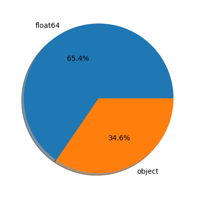

```python
tools.get_types_variables(df,True,True,True)
```

**Erreurs de formattage** :

- On convertie 'created_datetime','last_modified_datetime' en date

**Erreurs lexicales** : dans les colonnes 'created_datetime','last_modified_datetime

- On supprime les erreurs en les remplaçant par NaN

```python
# On supprime les erreurs
df.loc[df['created_datetime']=='Dia,Sogeres','created_datetime']='NaN'
df.loc[df['created_datetime']=='SuperU','created_datetime']='NaN'
df.loc[df['created_datetime']=='Carrefour','created_datetime']='NaN'
df.loc[df['created_datetime']=='Auchan','created_datetime']='NaN'
df.loc[df['created_datetime']=='Carrefour market','created_datetime']='NaN'
df.loc[df['created_datetime']=='SuperU,Leclerc','created_datetime']='NaN'
df.loc[df['created_datetime']=='Spar','created_datetime']='NaN'
df.loc[df['created_datetime']=='Banque alimentaire','created_datetime']='NaN'
df.loc[df['created_datetime']=='Leclerc','created_datetime']='NaN'
df.loc[df['created_datetime']=='Auchan,Super U','created_datetime']='NaN'
df.loc[df['created_datetime']=='Super U,Leclerc,Carrefour','created_datetime']='NaN'
df.loc[df['created_datetime']=='Cora','created_datetime']='NaN'
df.loc[df['created_datetime']=='Super U','created_datetime']='NaN'
df.loc[df['created_datetime']=='Super U,Leclerc,Carrefour','created_datetime']='NaN'

# On convertit la colonne created_datetime au format date
df["created_datetime"] =  pd.to_datetime(df["created_datetime"], format="%Y-%m-%dT%H:%M:%SZ")
```

```python
# On supprime les erreurs
df.loc[df['created_t']=='France','created_t']='NaN'
df.loc[df['created_t']=='Villecresnes,Villeurbanne,France','created_t']='NaN'
df.loc[df['created_t']=='Veynes,France','created_t']='NaN'
df.loc[df['created_t']=='Saint-Priest,France','created_t']='NaN'
df.loc[df['created_t']=='Torcy 77,France','created_t']='NaN'
df.loc[df['created_t']=='Villers Bocage 80260,France','created_t']='NaN'
df.loc[df['created_t']=='Montgermont','created_t']='NaN'
df.loc[df['created_t']=='Marseille 5°,France','created_t']='NaN'
df.loc[df['created_t']=='France,Nantes,Carquefou','created_t']='NaN'
df.loc[df['created_t']=='Courrières,France','created_t']='NaN'
df.loc[df['created_t']=='Brétigny-sur-Orge,Marseille 5°','created_t']='NaN'
df.loc[df['created_t']=='Brétigny-sur-Orge,Marseille 5°,France','created_t']='NaN'
df.loc[df['created_t']=='France','created_t']='NaN'

# On convertit la colonne created_t au format date
df['created_t'] = pd.to_datetime(df['created_t'],unit='s')
```

```python
# On supprime les erreurs
df.loc[df['last_modified_t']=='Belgique,France','last_modified_t']='NaN'
df.loc[df['last_modified_t']=='France','last_modified_t']='NaN'
df.loc[df['last_modified_t']=='Belgique,France, en:switzerland','last_modified_t']='NaN'
df.loc[df['last_modified_t']=='Suisse,France','last_modified_t']='NaN'

# On convertit la colonne last_modified_t au format date
df['last_modified_t'] = pd.to_datetime(df['last_modified_t'],unit='s')
```

```python
# On supprime les erreurs de saisie
# data.loc[data['montant']==-15000, 'montant'] = -14.39
df.loc[df['last_modified_datetime']=='en:belgium,en:france','last_modified_datetime']='NaN'
df.loc[df['last_modified_datetime']=='en:france','last_modified_datetime']='NaN'
df.loc[df['last_modified_datetime']=='en:belgium,en:france,en:switzerland','last_modified_datetime']='NaN'
df.loc[df['last_modified_datetime']=='en:france,en:switzerland','last_modified_datetime']='NaN'

# On convertit la colonne last_modified_dattetime au format date
df["last_modified_datetime"] =  pd.to_datetime(df["last_modified_datetime"], format="%Y-%m-%dT%H:%M:%SZ")
```

```python
df.head()
```

|  | code | url | creator | created_t | created_datetime | last_modified_t | last_modified_datetime | product_name | generic_name | quantity | packaging | packaging_tags | brands | brands_tags | categories | categories_tags | categories_fr | origins | origins_tags | manufacturing_places | manufacturing_places_tags | labels | labels_tags | labels_fr | emb_codes | emb_codes_tags | first_packaging_code_geo | cities | cities_tags | … |
| --- | --- | --- | --- | --- | --- | --- | --- | --- | --- | --- | --- | --- | --- | --- | --- | --- | --- | --- | --- | --- | --- | --- | --- | --- | --- | --- | --- | --- | --- | --- |
| 0 | 0000000003087 | http://world-fr.openfoodfacts.org/produit/0000... | openfoodfacts-contributors | 2016-09-17 09:17:46 | 2016-09-17 09:17:46 | 2016-09-17 09:18:13 | 2016-09-17 09:18:13 | Farine de blé noir | NaN | 1kg | NaN | NaN | Ferme t'y R'nao | ferme-t-y-r-nao | NaN | NaN | NaN | NaN | NaN | NaN | NaN | NaN | NaN | NaN | NaN | NaN | NaN | NaN | NaN | … |
| 1 | 0000000004530 | http://world-fr.openfoodfacts.org/produit/0000... | usda-ndb-import | 2017-03-09 14:32:37 | 2017-03-09 14:32:37 | 2017-03-09 14:32:37 | 2017-03-09 14:32:37 | Banana Chips Sweetened (Whole) | NaN | NaN | NaN | NaN | NaN | NaN | NaN | NaN | NaN | NaN | NaN | NaN | NaN | NaN | NaN | NaN | NaN | NaN | NaN | NaN | NaN | … |
| 2 | 0000000004559 | http://world-fr.openfoodfacts.org/produit/0000... | usda-ndb-import | 2017-03-09 14:32:37 | 2017-03-09 14:32:37 | 2017-03-09 14:32:37 | 2017-03-09 14:32:37 | Peanuts | NaN | NaN | NaN | NaN | Torn & Glasser | torn-glasser | NaN | NaN | NaN | NaN | NaN | NaN | NaN | NaN | NaN | NaN | NaN | NaN | NaN | NaN | NaN | … |
| 3 | 0000000016087 | http://world-fr.openfoodfacts.org/produit/0000... | usda-ndb-import | 2017-03-09 10:35:31 | 2017-03-09 10:35:31 | 2017-03-09 10:35:31 | 2017-03-09 10:35:31 | Organic Salted Nut Mix | NaN | NaN | NaN | NaN | Grizzlies | grizzlies | NaN | NaN | NaN | NaN | NaN | NaN | NaN | NaN | NaN | NaN | NaN | NaN | NaN | NaN | NaN | … |
| 4 | 0000000016094 | http://world-fr.openfoodfacts.org/produit/0000... | usda-ndb-import | 2017-03-09 10:34:13 | 2017-03-09 10:34:13 | 2017-03-09 10:34:13 | 2017-03-09 10:34:13 | Organic Polenta | NaN | NaN | NaN | NaN | Bob's Red Mill | bob-s-red-mill | NaN | NaN | NaN | NaN | NaN | NaN | NaN | NaN | NaN | NaN | NaN | NaN | NaN | NaN | NaN | … |

```
-------------------------------------------------------------
Type de variable pour chacune des variables
```

```
code                                                  object
url                                                   object
creator                                               object
created_t                                     datetime64[ns]
created_datetime                              datetime64[ns]
last_modified_t                               datetime64[ns]
last_modified_datetime                        datetime64[ns]
product_name                                          object
generic_name                                          object
quantity                                              object
packaging                                             object
packaging_tags                                        object
brands                                                object
brands_tags                                           object
categories                                            object
categories_tags                                       object
categories_fr                                         object
origins                                               object
origins_tags                                          object
manufacturing_places                                  object
manufacturing_places_tags                             object
labels                                                object
labels_tags                                           object
labels_fr                                             object
emb_codes                                             object
emb_codes_tags                                        object
first_packaging_code_geo                              object
cities                                                object
cities_tags                                           object
purchase_places                                       object
stores                                                object
countries                                             object
countries_tags                                        object
countries_fr                                          object
ingredients_text                                      object
allergens                                             object
allergens_fr                                          object
traces                                                object
traces_tags                                           object
traces_fr                                             object
```

[output cut: 108 more lines]

```
molybdenum_100g                                      float64
iodine_100g                                          float64
caffeine_100g                                        float64
taurine_100g                                         float64
ph_100g                                              float64
fruits-vegetables-nuts_100g                          float64
collagen-meat-protein-ratio_100g                     float64
cocoa_100g                                           float64
chlorophyl_100g                                      float64
carbon-footprint_100g                                float64
nutrition-score-fr_100g                              float64
nutrition-score-uk_100g                              float64
glycemic-index_100g                                  float64
water-hardness_100g                                  float64
dtype: object
```

```
----------------------------------------------------------
Répartition des types de variable
```

|  | Nombre par type de variable | % des types de variable |
| --- | --- | --- |
| float64 | 106 | 65.430000 |
| object | 52 | 32.100000 |
| datetime64[ns] | 4 | 2.470000 |

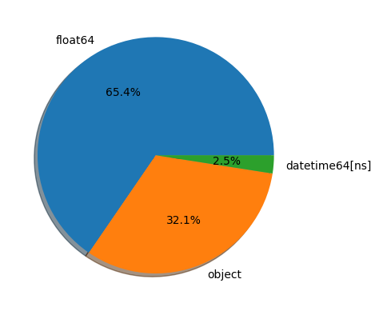

```python
tools.get_types_variables(df,True,True,True)
```

```python
# # On crée des listes selon type
# float_columns  = df.select_dtypes(include=['float64']).columns
# object_columns = df.select_dtypes(include=['object']).columns
# datetime_columns = df.select_dtypes(include=['datetime64[ns]']).columns
```

```python
# On crée une fonction pour la suite
def get_infos_df(df,types) :
    '''mise à jours des valeurs float_columns et objects'''
    float_columns  = df.select_dtypes(include=['float64']).columns
    object_columns = df.select_dtypes(include=['object']).columns
    datetime_columns = df.select_dtypes(include=['datetime64[ns]']).columns
    print("--------------GENERAL----------------------------------")
    print(f"taille df : {df.shape}")
    print("")
    if types:
        print("--------------OBJECT----------------------------------")
        print(f"Nombre de colonne du type Object : {df[object_columns].shape[1]}")
        print("---------->")
        print(f"{object_columns.to_list()}")
        print("")
        print("--------------FLOAT-----------------------------------")
        print(f"Nombre de colonne du type Float : {df[float_columns].shape[1]}")
        print("---------->")
        print(f"{float_columns.to_list()}")
        print("")
        print("--------------datetime64[ns]-----------------------------------")
        print(f"Nombre de colonne du type Float : {df[datetime_columns].shape[1]}")
        print("---------->")
        print(f"{datetime_columns.to_list()}")
# On affiche les listes par type
get_infos_df(df,types=True)
```

```
--------------GENERAL----------------------------------
taille df : (320772, 162)

--------------OBJECT----------------------------------
Nombre de colonne du type Object : 52
---------->
['code', 'url', 'creator', 'product_name', 'generic_name', 'quantity', 'packaging', 'packaging_tags', 'brands', 'brands_tags', 'categories', 'categories_tags', 'categories_fr', 'origins', 'origins_tags', 'manufacturing_places', 'manufacturing_places_tags', 'labels', 'labels_tags', 'labels_fr', 'emb_…

--------------FLOAT-----------------------------------
Nombre de colonne du type Float : 106
---------->
['no_nutriments', 'additives_n', 'ingredients_from_palm_oil_n', 'ingredients_from_palm_oil', 'ingredients_that_may_be_from_palm_oil_n', 'ingredients_that_may_be_from_palm_oil', 'nutrition_grade_uk', 'energy_100g', 'energy-from-fat_100g', 'fat_100g', 'saturated-fat_100g', 'butyric-acid_100g', 'caproi…

--------------datetime64[ns]-----------------------------------
Nombre de colonne du type Float : 4
---------->
['created_t', 'created_datetime', 'last_modified_t', 'last_modified_datetime']
```

### 2.2 Les NaN

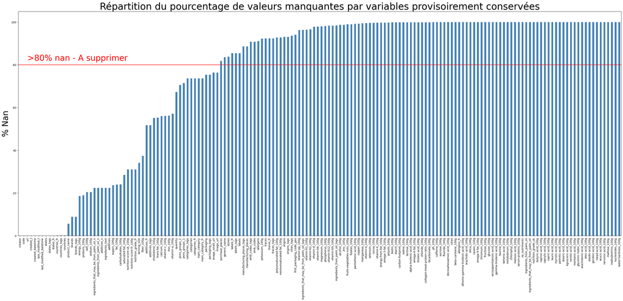

```python
# Répartition du pourcentage de valeurs manquantes pour toutes les variables provisoirement conservées
plt.figure(figsize=(40, 15))
df_app_nan = round((df.isna().sum()/df.shape[0])*100, 2)
df_app_nan.sort_values(inplace=True)
df_app_nan.plot(kind='bar', color='SteelBlue')
plt.title('Répartition du pourcentage de valeurs manquantes par variables provisoirement conservées', fontsize=35)
plt.ylabel('% Nan', fontsize=30)
plt.axhline(y=80, color='r')
plt.text(2, 82, '>80% nan - A supprimer', color='r', fontsize=30)
plt.show()
```

```python
# df = tools.suppression_variable_seuil_taux_nan(df,80)
```

```python
liste_colonne_jamais_utilisees =  tools.get_null_factor(df,80)
liste_colonne_jamais_utilisees
```

|  | Variables | Taux_de_Null |
| --- | --- | --- |
| 0 | water-hardness_100g | 100.000000 |
| 1 | no_nutriments | 100.000000 |
| 2 | ingredients_that_may_be_from_palm_oil | 100.000000 |
| 3 | nutrition_grade_uk | 100.000000 |
| 4 | nervonic-acid_100g | 100.000000 |
| 5 | erucic-acid_100g | 100.000000 |
| 6 | mead-acid_100g | 100.000000 |
| 7 | elaidic-acid_100g | 100.000000 |
| 8 | butyric-acid_100g | 100.000000 |
| 9 | caproic-acid_100g | 100.000000 |
| 10 | ingredients_from_palm_oil | 100.000000 |
| 11 | lignoceric-acid_100g | 100.000000 |
| 12 | cerotic-acid_100g | 100.000000 |
| 13 | melissic-acid_100g | 100.000000 |
| 14 | chlorophyl_100g | 100.000000 |
| 15 | glycemic-index_100g | 100.000000 |
| 16 | myristic-acid_100g | 99.999688 |
| 17 | palmitic-acid_100g | 99.999688 |
| 18 | caprylic-acid_100g | 99.999688 |
| 19 | stearic-acid_100g | 99.999688 |
| 20 | montanic-acid_100g | 99.999688 |
| 21 | capric-acid_100g | 99.999377 |
| 22 | maltose_100g | 99.998753 |
| 23 | lauric-acid_100g | 99.998753 |
| 24 | arachidonic-acid_100g | 99.997506 |
| 25 | nucleotides_100g | 99.997194 |
| 26 | maltodextrins_100g | 99.996571 |
| 27 | molybdenum_100g | 99.996571 |
| 28 | oleic-acid_100g | 99.995947 |
| 29 | gondoic-acid_100g | 99.995636 |

[output cut: 78 more lines]

```python
# On supprime les variables jamais utilisées
old_nb_col = df.shape[1]
elem = liste_colonne_jamais_utilisees['Variables']
df = df.drop(columns=liste_colonne_jamais_utilisees['Variables'],axis=1)
print(f"On a supprimé {old_nb_col - df.shape[1]} colonnes")
```

```
On a supprimé 108 colonnes
```

```
Nombre total de données manquantes dans le dataframe : 5771467 données manquantes sur 17321688 (33.32%)
-------------------------------------------------------------
Nombre et pourcentage de valeurs manquantes par variable
```

|  | Nombres de valeurs manquantes | % de valeurs manquantes |
| --- | --- | --- |
| image_url | 244936 | 76.360000 |
| image_small_url | 244936 | 76.360000 |
| packaging_tags | 241811 | 75.380000 |
| packaging | 241812 | 75.380000 |
| main_category_fr | 236406 | 73.700000 |
| main_category | 236406 | 73.700000 |
| categories | 236362 | 73.690000 |
| categories_tags | 236383 | 73.690000 |
| categories_fr | 236361 | 73.690000 |
| pnns_groups_1 | 229259 | 71.470000 |
| pnns_groups_2 | 226281 | 70.540000 |
| quantity | 215953 | 67.320000 |
| vitamin-a_100g | 183218 | 57.120000 |
| iron_100g | 180310 | 56.210000 |
| vitamin-c_100g | 179905 | 56.090000 |
| calcium_100g | 179722 | 56.030000 |
| trans-fat_100g | 177474 | 55.330000 |
| cholesterol_100g | 176682 | 55.080000 |
| additives_tags | 166092 | 51.780000 |
| additives_fr | 166092 | 51.780000 |
| fiber_100g | 119886 | 37.370000 |
| serving_size | 109441 | 34.120000 |
| nutrition-score-fr_100g | 99562 | 31.040000 |
| nutrition_grade_fr | 99562 | 31.040000 |
| nutrition-score-uk_100g | 99562 | 31.040000 |
| saturated-fat_100g | 91218 | 28.440000 |
| carbohydrates_100g | 77184 | 24.060000 |
| fat_100g | 76881 | 23.970000 |
| sugars_100g | 75801 | 23.630000 |
| additives | 71867 | 22.400000 |
| ingredients_text | 71810 | 22.390000 |
| ingredients_that_may_be_from_palm_oil_n | 71833 | 22.390000 |
| ingredients_from_palm_oil_n | 71833 | 22.390000 |
| additives_n | 71833 | 22.390000 |
| sodium_100g | 65309 | 20.360000 |
| salt_100g | 65262 | 20.350000 |
| proteins_100g | 60850 | 18.970000 |
| energy_100g | 59659 | 18.600000 |
| brands_tags | 28420 | 8.860000 |
| brands | 28412 | 8.860000 |
| product_name | 17762 | 5.540000 |
| countries_tags | 280 | 0.090000 |
| countries | 280 | 0.090000 |
| countries_fr | 280 | 0.090000 |
| states_fr | 46 | 0.010000 |
| last_modified_t | 23 | 0.010000 |
| created_t | 23 | 0.010000 |
| created_datetime | 24 | 0.010000 |
| url | 23 | 0.010000 |
| last_modified_datetime | 23 | 0.010000 |
| states | 46 | 0.010000 |
| states_tags | 46 | 0.010000 |
| code | 23 | 0.010000 |
| creator | 2 | 0.000000 |

```
------------------------------------------------------------------
Visualisation des données manquantes
```

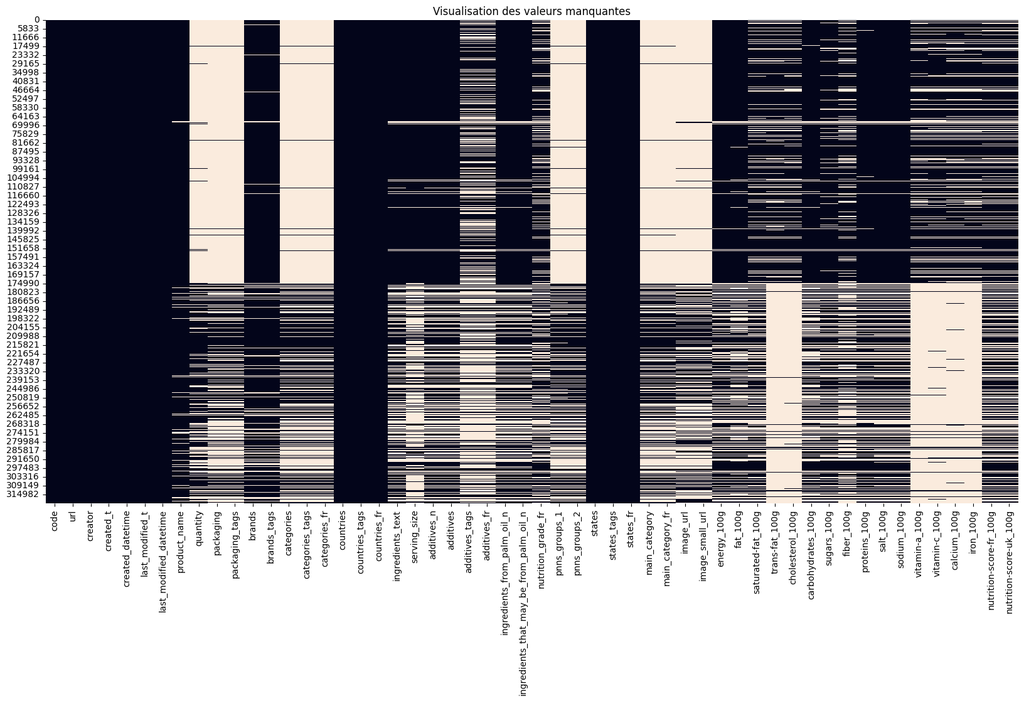

```python
tools.get_missing_value(df,True,True)
```

```python
get_infos_df(df,types=False)
```

```
--------------GENERAL----------------------------------
taille df : (320772, 54)
```

# 3.1 On explore les GENERAL INFORMATION

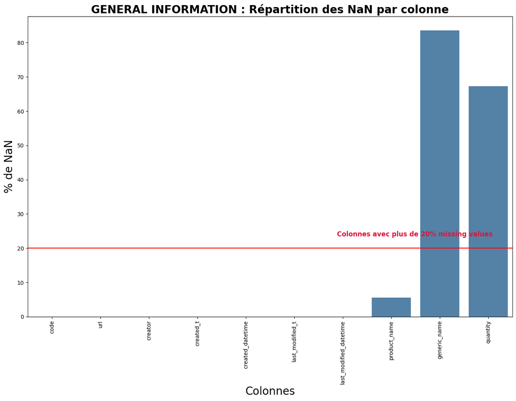

```python
# On affiche la répartition des NaN
# Les informations
tools.graph_NAN(data,20,0,10,"GENERAL INFORMATION : Répartition des NaN par colonne")
```

```python
def info_list_colonnes(df,liste_col,_unique):
    '''
    Information sur les colonnes seeléctionnées
    paramètres :
    - df
    - list_col : liste des colonne a considérer
    '''
    for i in liste_col:

        df_work = df[i]
        print("________")
        print(f"Colonne : {i}")
        print(f"Nombre de valeurs uniques : {df_work.nunique()}")
        print(f"Type de la variable       : {df[i].dtypes}")
        print(f"NaN                       : {round(df_work.isnull().mean()*100,2)} %")
        if _unique:
            print(f"Valeurs unique            : {df[i].unique()}")
        print("")
```

```python
# List des colonnes information general
liste_information_general = df.iloc[:,10:34].columns
info_list_colonnes(df,liste_information_general,True)
```

```
________
Colonne : packaging_tags
Nombre de valeurs uniques : 12064
Type de la variable       : object
NaN                       : 75.38 %
Valeurs unique            : [nan 'plastique' 'frais' ... 'carton,tetra-pak,brique'
 'sachets,emballage-individuel' 'tetra-pak,brique,tetra-pak']

________
Colonne : brands
Nombre de valeurs uniques : 58784
Type de la variable       : object
NaN                       : 8.86 %
Valeurs unique            : ["Ferme t'y R'nao" nan 'Torn & Glasser' ... 'Roussette du Bugey'
 'Sans marque,D.Lambert' '乐吧']

________
Colonne : brands_tags
Nombre de valeurs uniques : 50253
Type de la variable       : object
NaN                       : 8.86 %
Valeurs unique            : ['ferme-t-y-r-nao' nan 'torn-glasser' ... 'roussette-du-bugey'
 'sans-marque,d-lambert' '乐吧']

________
Colonne : categories
Nombre de valeurs uniques : 36982
Type de la variable       : object
NaN                       : 73.69 %
Valeurs unique            : [nan 'Filet de bœuf' 'Légumes-feuilles' ...
 'Boissons,Boissons alcoolisées,Vins,Vins blancs,Roussette du Bugey'
 'pl:Szprot'
 "Viandes,Produits à tartiner,Charcuteries,Produits à tartiner salés,Rillettes,Rillettes de viande,Rillettes de viande blanche,Rillettes de volaille,Rillettes d'oie"]

________
Colonne : categories_tags
Nombre de valeurs uniques : 21142
Type de la variable       : object
NaN                       : 73.69 %
Valeurs unique            : [nan 'fr:filet-de-boeuf'
```

[output cut: 942 more lines]

```
Valeurs unique            : ['A compléter,Informations nutritionnelles à compléter,Ingrédients à compléter,Date limite à compléter,Caractéristiques à compléter,Catégories à compléter,Marques complétées,Emballage à compléter,Quantité complétée,Nom du produit complete,Photos à valider,Photos envoyées'
 'A compléter,Informations nutritionnelles complétées,Ingrédients complétés,Date limite à compléter,en:Packaging-code-to-be-completed,Caractéristiques à compléter,Catégories à compléter,Marques à compléter,Emballage à compléter,Quantité à compléter,Nom du produit complete,Photos à envoyer'
 'A compléter,Informations nutritionnelles complétées,Ingrédients complétés,Date limite à compléter,en:Packaging-code-to-be-completed,Caractéristiques à compléter,Catégories à compléter,Marques complétées,Emballage à compléter,Quantité à compléter,Nom du produit complete,Photos à envoyer'
 ...
 'A compléter,Informations nutritionnelles à compléter,Ingrédients à compléter,Date limite complétée,en:Packaging-code-to-be-completed,Caractéristiques à compléter,Catégories complétées,Marques complétées,Emballage complété,Quantité à compléter,Nom du produit complete,Photos validées,Photos envoyées…
 'A compléter,Informations nutritionnelles complétées,Ingrédients à compléter,Date limite complétée,en:Packaging-code-to-be-completed,Caractéristiques à compléter,Catégories à compléter,Marques à compléter,Emballage à compléter,Quantité complétée,Nom du produit complete,Photos à envoyer'
 'A compléter,Informations nutritionnelles complétées,Ingrédients complétés,Date limite à compléter,en:Packaging-code-to-be-completed,Caractéristiques à compléter,Catégories à compléter,Marques complétées,Emballage complété,Quantité à compléter,Nom du produit complete,Photos à envoyer']

________
Colonne : main_category
Nombre de valeurs uniques : 3543
Type de la variable       : object
NaN                       : 73.7 %
Valeurs unique            : [nan 'fr:filet-de-boeuf' 'en:fresh-vegetables' ... 'fr:sauce-a-l-ail'
 'fr:attieke' 'pl:szprot']
```

#### Recherche des doublons (colonnes)

```python
datetime_columns= df.select_dtypes(include=['datetime64[ns]']).columns
datetime_columns.to_list()
```

```
['created_t', 'created_datetime', 'last_modified_t', 'last_modified_datetime']
```

```python
df['created_t'].equals(df['created_datetime'])
```

```
False
```

```python
df['last_modified_t'].equals(df['last_modified_datetime'])
```

```
True
```

#### Recherche des doublons (lignes)

```python
def search_doublons_col(df,col):
    """
    affiche la liste des doublons de df
    """
    liste_doublon = df[df.duplicated([col],keep=False)]
    print(f"Il y a : {liste_doublon.shape[0]} doublons dans les codes produits : Ils ont NaN en tant que code")
    liste_doublon
```

```python
def supp_doublons_col(df,col):
    nb_ligne_avant = df.shape[0]
    df = df.dropna(subset=['code'])
    print(f"Réduction du nombre de lignes : on passe de {nb_ligne_avant} à {df.shape[0]} lignes on a supprimmé {nb_ligne_avant - df.shape[0]} lignes")
```

```python
# On compte les doublons dans les codes qui doivent être unique
search_doublons_col(df,'code')
```

```
Il y a : 23 doublons dans les codes produits : Ils ont NaN en tant que code
```

```python
supp_doublons_col(df,'code')
```

```
Réduction du nombre de lignes : on passe de 320772 à 320749 lignes on a supprimmé 23 lignes
```

### 3.1.1 Créateurs

```python
creators = df.groupby(by='creator')['code'].nunique().sort_values(ascending=False)
```

```python
def plot_contributor(n=5):
    fig, ax = plt.subplots(figsize=(8, 8), subplot_kw=dict(aspect="equal"))

    explodes = np.zeros(n)
    explodes[0] = .1

    def pct_tot(pct):
        tot = round(pct*creators[:n].sum(),0)
        tot_pct = tot/creators.sum()
        return "{:.1f}%\n({:.0f})".format(tot_pct,(tot/100))

    plt.pie(creators[:n], labels=creators[:n].index,
            startangle=45,
            shadow=True,
            explode=explodes,
            autopct=lambda pct: pct_tot(pct),
            textprops=dict(color="black",size=12, weight="bold"))
    plt.title("Les {:d} meilleurs contributeurs".format(n),
              fontweight='bold',fontsize=24)
    plt.show()
```

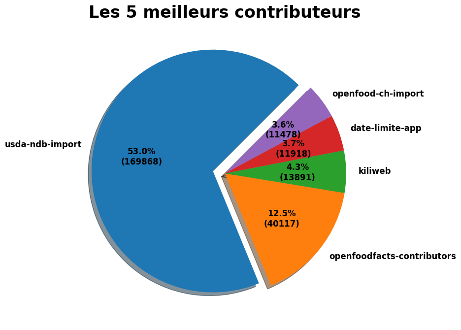

```python
plot_contributor(n=5)
```

### 3.1.1 Les dates

```python
# On visualise les variables date
df[datetime_columns].head()
```

|  | created_t | created_datetime | last_modified_t | last_modified_datetime |
| --- | --- | --- | --- | --- |
| 0 | 2016-09-17 09:17:46 | 2016-09-17 09:17:46 | 2016-09-17 09:18:13 | 2016-09-17 09:18:13 |
| 1 | 2017-03-09 14:32:37 | 2017-03-09 14:32:37 | 2017-03-09 14:32:37 | 2017-03-09 14:32:37 |
| 2 | 2017-03-09 14:32:37 | 2017-03-09 14:32:37 | 2017-03-09 14:32:37 | 2017-03-09 14:32:37 |
| 3 | 2017-03-09 10:35:31 | 2017-03-09 10:35:31 | 2017-03-09 10:35:31 | 2017-03-09 10:35:31 |
| 4 | 2017-03-09 10:34:13 | 2017-03-09 10:34:13 | 2017-03-09 10:34:13 | 2017-03-09 10:34:13 |

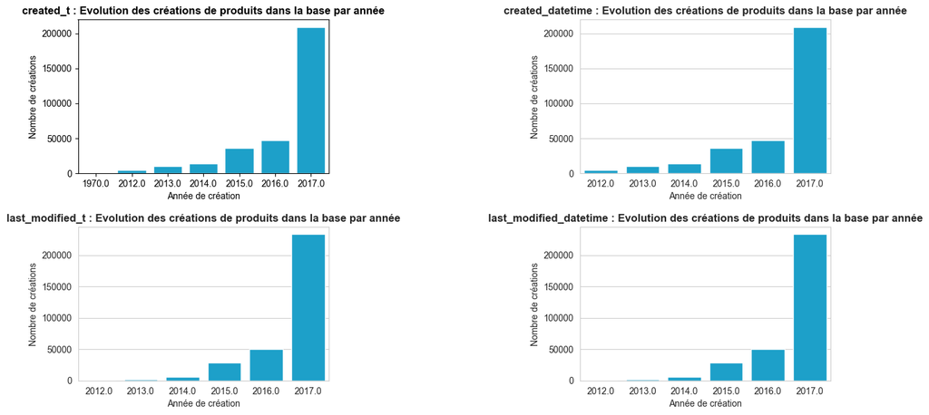

```python
plt.figure(figsize=(15, 15), dpi=100)  # taille

plt.subplot(4, 2, 1)
add_per_year = df[['created_t', 'code']].groupby(by=df['created_t'].dt.year).nunique()
sns.set_style("whitegrid")
sns.barplot(data=add_per_year, x=add_per_year.index, y='code', color='#00afe6')
plt.title("created_t : Evolution des créations de produits dans la base par année",fontweight='bold')
plt.xlabel("Année de création")
plt.ylabel("Nombre de créations")

plt.subplot(4, 2, 2)
add_per_year = df[['created_datetime', 'code']].groupby(by=df['created_datetime'].dt.year).nunique()
sns.set_style("whitegrid")
sns.barplot(data=add_per_year, x=add_per_year.index, y='code', color='#00afe6')
plt.title("created_datetime : Evolution des créations de produits dans la base par année",fontweight='bold')
plt.xlabel("Année de création")
plt.ylabel("Nombre de créations")

plt.subplot(4, 2, 3)
add_per_year = df[['last_modified_t', 'code']].groupby(by=df['last_modified_t'].dt.year).nunique()
sns.set_style("whitegrid")
sns.barplot(data=add_per_year, x=add_per_year.index, y='code', color='#00afe6')
plt.title("last_modified_t : Evolution des créations de produits dans la base par année",fontweight='bold')
plt.xlabel("Année de création")
plt.ylabel("Nombre de créations")

plt.subplot(4, 2, 4)
add_per_year = df[['last_modified_datetime', 'code']].groupby(by=df['last_modified_datetime'].dt.year).nunique()
sns.set_style("whitegrid")
sns.barplot(data=add_per_year, x=add_per_year.index, y='code', color='#00afe6')
plt.title("last_modified_datetime : Evolution des créations de produits dans la base par année",fontweight='bold')
plt.xlabel("Année de création")
plt.ylabel("Nombre de créations")
plt.subplots_adjust(left=0.125, bottom=0.1, right=0.9, top=0.9, wspace=1, hspace=0.35)
plt.show()
```

Quelle que soit les valeurs faisant référence aux dates : on observe un augmentation significative dans les années 2015-2017

- created_t dispose d'information remontant à 1970 : il est possible que ce soit des erreurs de saisie nous pourrions les traiter quand nous verrons les outliers mais comme les nombres de variables sont similaire nous pensons garder les valeurs les plus à jours : **last_modified_datetime**
- Explication des dates :
  - Le Nutri-Score est prévu dans la loi de 2016 en France
  - Mis en place en France en 2017, l'étiquetage nutritionnel Nutri-Score s'applique aujourd'hui dans sept pays

### 3.1.3 Les produits

```python
# Les products name les plus présent
effectifs = df["product_name"].value_counts()
modalites = effectifs.index # contient les modalités
tab = pd.DataFrame(modalites, columns = ["Product_name"]) # création du tableau à partir des modalités
tab["n"] = effectifs.values
tab = tab.sort_values("n",ascending=False) # tri des valeurs de la variable X (croissant)
```

```python
# On affiche les produits qui apparaissent le plus
tab.head(10)
```

|  | Product_name | n |
| --- | --- | --- |
| 0 | Ice Cream | 410 |
| 1 | Extra Virgin Olive Oil | 303 |
| 2 | Potato Chips | 281 |
| 3 | Premium Ice Cream | 226 |
| 4 | Tomato Ketchup | 182 |
| 5 | Beef Jerky | 167 |
| 6 | Pinto Beans | 162 |
| 7 | Popcorn | 157 |
| 8 | Cookies | 155 |
| 9 | Salsa | 150 |

- Suppression des produits sans nom (product_name)

```python
# Supprimer les produit qui n'ont pas de nom
old_product_shape=df.shape[0]
df = df[~(df['product_name'].isnull())]
print(f"On a supprimé {old_product_shape - df.shape[0]}  produits sans nom")
```

```
On a supprimé 17762  produits sans nom
```

```python
df.shape
```

```
(303010, 54)
```

```python
data.shape[1] - df.shape[1]
```

```
108
```

- **Variables exclues** :
  - code : barcode of the product (can be EAN-13 or internal codes for some food stores)
  - url : url of the product page on Open Food Facts
  - creator : contributor who first added the product (redontante avec last_modified_t )
  - created_t : date that the product was added.sum() (UNIX timestamp format) (redontante avec last_modified_t )
  - created_datetime : date that the product was added (iso8601 format: yyyy-mm-ddThh:mn:ssZ)
  - last_modified_datetime (redontante avec last_modified_t)
  - generic_name (84% de na)
  - quantity : quantity and unit : 13826 unités et quantités différentes
- **Variables conservées** :
  - **last_modified_t** : date that the product page was last modified (dernières valeurs)
  - **product_name** : name of the product

```python
coll_gen = ['last_modified_t','product_name']
```

# 3.2 On explore les TAGS

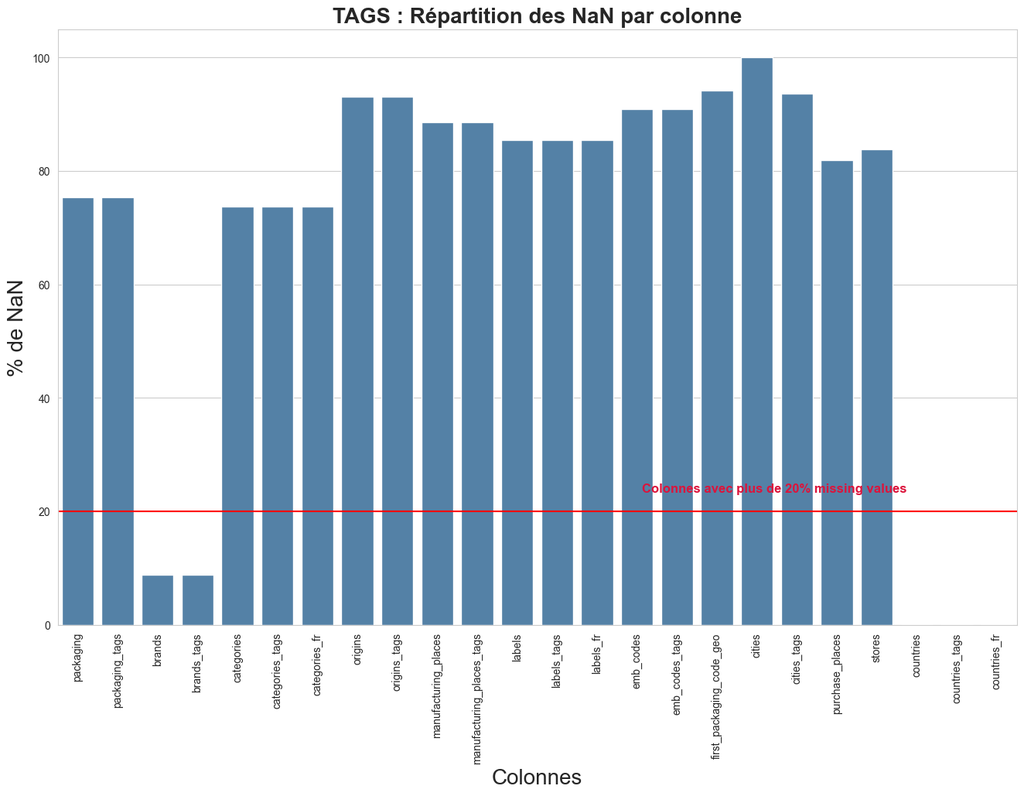

```python
# On affiche les NaN des colonnes TAGS
tools.graph_NAN(data,20,10,34,"TAGS : Répartition des NaN par colonne")
```

```python
liste_tags = df.iloc[:,10:34].columns
info_list_colonnes(df,liste_tags,True)
```

```
________
Colonne : packaging_tags
Nombre de valeurs uniques : 12022
Type de la variable       : object
NaN                       : 74.09 %
Valeurs unique            : [nan 'plastique' 'frais' ... 'carton,tetra-pak,brique'
 'sachets,emballage-individuel' 'tetra-pak,brique,tetra-pak']

________
Colonne : brands
Nombre de valeurs uniques : 58390
Type de la variable       : object
NaN                       : 4.31 %
Valeurs unique            : ["Ferme t'y R'nao" nan 'Torn & Glasser' ... 'Roussette du Bugey'
 'Sans marque,D.Lambert' '乐吧']

________
Colonne : brands_tags
Nombre de valeurs uniques : 49933
Type de la variable       : object
NaN                       : 4.32 %
Valeurs unique            : ['ferme-t-y-r-nao' nan 'torn-glasser' ... 'roussette-du-bugey'
 'sans-marque,d-lambert' '乐吧']

________
Colonne : categories
Nombre de valeurs uniques : 36653
Type de la variable       : object
NaN                       : 72.47 %
Valeurs unique            : [nan 'Filet de bœuf' 'Légumes-feuilles' ...
 'Boissons,Boissons alcoolisées,Vins,Vins blancs,Roussette du Bugey'
 'pl:Szprot'
 "Viandes,Produits à tartiner,Charcuteries,Produits à tartiner salés,Rillettes,Rillettes de viande,Rillettes de viande blanche,Rillettes de volaille,Rillettes d'oie"]

________
Colonne : categories_tags
Nombre de valeurs uniques : 20932
Type de la variable       : object
NaN                       : 72.48 %
Valeurs unique            : [nan 'fr:filet-de-boeuf'
```

[output cut: 3072 more lines]

```
 'A compléter,Informations nutritionnelles complétées,Ingrédients complétés,Date limite complétée,en:Packaging-code-to-be-completed,Caractéristiques à compléter,Catégories complétées,Marques à compléter,Emballage complété,Quantité à compléter,Nom du produit complete,Photos à valider,Photos envoyées'
 'A compléter,Informations nutritionnelles à compléter,Ingrédients complétés,Date limite à compléter,en:Packaging-code-to-be-completed,Caractéristiques à compléter,Catégories à compléter,Marques complétées,Emballage complété,Quantité complétée,Nom du produit complete,Photos validées,Photos envoyées'
 'A compléter,Informations nutritionnelles complétées,Ingrédients complétés,Date limite à compléter,Caractéristiques à compléter,Catégories à compléter,Marques à compléter,Emballage complété,Quantité à compléter,Nom du produit complete,Photos à envoyer'
 'A compléter,Informations nutritionnelles à compléter,Ingrédients à compléter,Date limite à compléter,Caractéristiques à compléter,Catégories à compléter,Emballage à compléter,Photos à valider,Photos envoyées'
 'A compléter,Informations nutritionnelles à compléter,Ingrédients à compléter,Date limite complétée,en:Packaging-code-to-be-completed,Caractéristiques à compléter,Catégories complétées,Marques complétées,Emballage complété,Quantité à compléter,Nom du produit complete,Photos validées,Photos envoyées…
 'A compléter,Informations nutritionnelles complétées,Ingrédients à compléter,Date limite complétée,en:Packaging-code-to-be-completed,Caractéristiques à compléter,Catégories à compléter,Marques à compléter,Emballage à compléter,Quantité complétée,Nom du produit complete,Photos à envoyer'
 'A compléter,Informations nutritionnelles complétées,Ingrédients complétés,Date limite à compléter,en:Packaging-code-to-be-completed,Caractéristiques à compléter,Catégories à compléter,Marques complétées,Emballage complété,Quantité à compléter,Nom du produit complete,Photos à envoyer']

________
Colonne : main_category
Nombre de valeurs uniques : 3447
Type de la variable       : object
NaN                       : 72.49 %
Valeurs unique            : [nan 'fr:filet-de-boeuf' 'en:fresh-vegetables' ... 'fr:sauce-a-l-ail'
 'fr:attieke' 'pl:szprot']
```

### 3.2.1 Les categories

```python
category_columns = ['categories','categories_tags','categories_fr','main_category','main_category_fr']
df[df[category_columns].notnull().any(axis=1)][ category_columns].sample(5)
```

|  | categories | categories_tags | categories_fr | main_category | main_category_fr |
| --- | --- | --- | --- | --- | --- |
| 208292 | Laits demi-écrémés,Laits microfiltrés,Laits frais | en:dairies,en:milks,en:fresh-milks,en:semi-ski... | Produits laitiers,Laits,Laits frais,Laits demi... | en:milks | Laits |
| 191908 | Blocs de foie gras,Foies gras de canard | en:fish-and-meat-and-eggs,fr:foies-gras,fr:blo... | Poissons et viandes et oeufs,Foies gras,Bloc d... | en:fish-and-meat-and-eggs | Poissons et viandes et oeufs |
| 199870 | Snacks sucrés,Biscuits et gâteaux,Biscuits,Gén... | en:sugary-snacks,en:biscuits-and-cakes,en:bisc... | Snacks sucrés,Biscuits et gâteaux,Biscuits,Gen... | en:biscuits | Biscuits |
| 200753 | Chips | en:salty-snacks,en:appetizers,en:chips-and-fri... | Snacks salés,Apéritif,Chips et frites,Chips | en:chips-and-fries | Chips et frites |
| 192915 | Poêlées surgelées,Plats cuisinés surgelés | en:frozen-foods,en:meals,en:frozen-ready-made-... | Surgelés,Plats préparés,Plats préparés surgelé... | en:frozen-foods | Surgelés |

- **On ajoute main_category et main_category_fr**

### 3.2.2 Produits et Marques

```python
products_colums = ['product_name']
df[df[category_columns].notnull().any(axis=1)][['product_name']].sample(5)
```

|  | product_name |
| --- | --- |
| 180698 | Bircher Muesli |
| 242677 | Yaourt à boire à la paille |
| 303243 | Il gelato 8 sandwich |
| 269150 | Worcestershire Sauce |
| 246536 | Velouté de légumes du soleil |

```python
df_gen_dup = df.loc[df[coll_gen].duplicated(keep=False),:]
```

```python
df_gen_dup[["product_name","brands"]].head(6)
df_gen_dup.head()
```

|  | code | url | creator | created_t | created_datetime | last_modified_t | last_modified_datetime | product_name | quantity | packaging | packaging_tags | brands | brands_tags | categories | categories_tags | categories_fr | countries | countries_tags | countries_fr | ingredients_text | serving_size | additives_n | additives | additives_tags | additives_fr | ingredients_from_palm_oil_n | ingredients_that_may_be_from_palm_oil_n | nutrition_grade_fr | pnns_groups_1 | … |
| --- | --- | --- | --- | --- | --- | --- | --- | --- | --- | --- | --- | --- | --- | --- | --- | --- | --- | --- | --- | --- | --- | --- | --- | --- | --- | --- | --- | --- | --- | --- |
| 198 | 0000020043070 | http://world-fr.openfoodfacts.org/produit/0000... | usda-ndb-import | 2017-03-10 08:49:40 | 2017-03-10 08:49:40 | 2017-03-10 08:49:40 | 2017-03-10 08:49:40 | Biscuit | NaN | NaN | NaN | Fresh & Easy | fresh-easy | NaN | NaN | NaN | US | en:united-states | États-Unis | Enriched wheat flour (niacin, reduced iron, th... | 75 g (1 PIECE) | 3.0 | [ enriched-wheat-flour -> en:enriched-wheat-f... | en:e375,en:e101,en:e410 | E375 - Acide nicotinique,E101 - Riboflavine,E4... | 0.0 | 0.0 | e | NaN | … |
| 199 | 0000020043087 | http://world-fr.openfoodfacts.org/produit/0000... | usda-ndb-import | 2017-03-10 08:49:40 | 2017-03-10 08:49:40 | 2017-03-10 08:49:40 | 2017-03-10 08:49:40 | Biscuit | NaN | NaN | NaN | Fresh & Easy | fresh-easy | NaN | NaN | NaN | US | en:united-states | États-Unis | Enriched wheat flour (niacin, reduced iron, th... | 75 g (1 PIECE) | 3.0 | [ enriched-wheat-flour -> en:enriched-wheat-f... | en:e375,en:e101,en:e410 | E375 - Acide nicotinique,E101 - Riboflavine,E4... | 0.0 | 0.0 | d | NaN | … |
| 205 | 0000020045791 | http://world-fr.openfoodfacts.org/produit/0000... | usda-ndb-import | 2017-03-10 08:39:36 | 2017-03-10 08:39:36 | 2017-03-10 08:39:36 | 2017-03-10 08:39:36 | Muffin | NaN | NaN | NaN | Fresh & Easy | fresh-easy | NaN | NaN | NaN | US | en:united-states | États-Unis | Wheatflour, sugar, eggs, soybean oil, water, c... | 170 g (1 MUFFIN) | 2.0 | [ wheatflour -> en:wheatflour ] [ sugar -> ... | en:e322,en:e500ii | E322 - Lécithines,E500ii - Hydrogénocarbonate ... | 0.0 | 0.0 | d | NaN | … |
| 206 | 0000020045807 | http://world-fr.openfoodfacts.org/produit/0000... | usda-ndb-import | 2017-03-10 08:39:36 | 2017-03-10 08:39:36 | 2017-03-10 08:39:36 | 2017-03-10 08:39:36 | Muffin | NaN | NaN | NaN | Fresh & Easy | fresh-easy | NaN | NaN | NaN | US | en:united-states | États-Unis | Enriched wheat flour (wheat flour, malted barl... | 170 g (1 MUFFIN) | 3.0 | [ enriched-wheat-flour -> en:enriched-wheat-f... | en:e375,en:e101,en:e450 | E375 - Acide nicotinique,E101 - Riboflavine,E4... | 0.0 | 0.0 | d | NaN | … |
| 261 | 0000159479269 | http://world-fr.openfoodfacts.org/produit/0000... | usda-ndb-import | 2017-03-09 16:01:55 | 2017-03-09 16:01:55 | 2017-03-09 16:01:56 | 2017-03-09 16:01:56 | Magic Stars Chocolates | NaN | NaN | NaN | Milkyway | milkyway | NaN | NaN | NaN | US | en:united-states | États-Unis | Sugar, cocoa butter, skimmed milk powder, coco... | 100 g (100 GRM) | 1.0 | [ sugar -> en:sugar ] [ cocoa-butter -> en:... | en:e322 | E322 - Lécithines | 0.0 | 0.0 | NaN | NaN | … |

- **Suppression de lignes**

```python
old_shape = df.shape[0]
# On supprime les doublons des produits de la même marque en conservant les valeurs nulles
df = df[(~df.duplicated(["product_name","brands"],keep="last")) | ((df['product_name'].isnull()) & (df['brands'].isnull()))]
print(f"On a supprimé : {old_shape - df.shape[0]} lignes en doublons")
```

```
On a supprimé : 20520 lignes en doublons
```

```python
df.shape
```

```
(282490, 54)
```

### 3.2.3 Les Pays

```python
# On compare les colonnes qui enregistrent les pays
countries_columns = ['countries','countries_tags','countries_fr']
df[df[category_columns].notnull().any(axis=1)][ countries_columns].sample(5)
```

|  | countries | countries_tags | countries_fr |
| --- | --- | --- | --- |
| 55295 | United Kingdom | en:united-kingdom | Royaume-Uni |
| 229955 | France | en:france | France |
| 246034 | France | en:france | France |
| 279142 | Belgium,France,Hungary,Italy,Quebec | en:belgium,en:france,en:hungary,en:italy,en:qu... | Belgique,France,Hongrie,Italie,en:Quebec |
| 225238 | France | en:france | France |

```python
# On comptes le nombre de pays selon les colonnes
print(f"countries : nombre de pays : {df['countries'].nunique()}")
print(f"countries_tags : nombre de pays : {df['countries_tags'].nunique()}")
print(f"countries_fr : nombre de pays : {df['countries_fr'].nunique()}")
```

```
countries : nombre de pays : 1304
countries_tags : nombre de pays : 661
countries_fr : nombre de pays : 657
```

```python
countries_fr = df.groupby(by="countries_fr").nunique()
countries_fr[['code']].head()
```

| countries_fr | code |
| --- | --- |
| Afrique du Sud | 32 |
| Albanie | 5 |
| Albanie,Danemark,Italie | 1 |
| Albanie,Italie | 4 |
| Algérie | 81 |

```python
countries = df.groupby(by="countries").nunique()
countries[['code']].head()
```

| countries | code |
| --- | --- |
| ALLEMAGNE | 1 |
| Albania | 2 |
| Albania,Italia | 1 |
| Albania,Italia, en:denmark | 1 |
| Albania,Italy | 3 |

- **On choisit countries_fr pour ses valeurs en Français**

```python
# tableau des effectifs
def tab_effectifs(df,col):
    effectifs = df[col].value_counts()
    modalites = effectifs.index # contient les modalités
    tab = pd.DataFrame(modalites, columns = [col]) # création du tableau à partir des modalités
    tab["n"] = effectifs.values
    tab = tab.sort_values("n",ascending=False) # tri des valeurs de la variable X (croissant)
    return tab
```

```python
tab_effectifs(df,'countries_fr')
```

|  | countries_fr | n |
| --- | --- | --- |
| 0 | États-Unis | 157080 |
| 1 | France | 83803 |
| 2 | Suisse | 10903 |
| 3 | Allemagne | 6551 |
| 4 | Espagne | 4390 |
| 5 | Royaume-Uni | 3492 |
| 6 | Belgique | 1859 |
| 7 | Australie | 1588 |
| 8 | Russie | 1204 |
| 9 | France,Suisse | 1110 |
| 10 | Italie | 938 |
| 11 | Canada | 667 |
| 12 | Portugal | 543 |
| 13 | Pays-Bas | 490 |
| 14 | Belgique,France | 464 |
| 15 | France,Royaume-Uni | 397 |
| 16 | Brésil | 307 |
| 17 | République tchèque | 258 |
| 18 | Autriche | 235 |
| 19 | Danemark | 222 |
| 20 | France,Allemagne | 220 |
| 21 | Allemagne,Suisse | 192 |
| 22 | France,États-Unis | 190 |
| 23 | Irlande | 163 |
| 24 | Roumanie | 157 |
| 25 | Chine | 144 |
| 26 | France,Espagne | 140 |
| 27 | Hongrie | 138 |
| 28 | Pologne | 118 |
| 29 | Luxembourg | 116 |

[output cut: 627 more lines]

```python
# Dans les cas de plusieurs pays dans une cellule on conserve le premier
df['countries_fr'] = df['countries_fr'].str.split(',', n=1, expand=True)[0]
```

```python
# on visualise
tab_effectifs(df,'countries_fr')
```

|  | countries_fr | n |
| --- | --- | --- |
| 0 | États-Unis | 157094 |
| 1 | France | 86492 |
| 2 | Suisse | 10987 |
| 3 | Allemagne | 6826 |
| 4 | Espagne | 4417 |
| 5 | Royaume-Uni | 3528 |
| 6 | Belgique | 2601 |
| 7 | Australie | 1672 |
| 8 | Russie | 1207 |
| 9 | Italie | 962 |
| 10 | Canada | 724 |
| 11 | Portugal | 579 |
| 12 | Pays-Bas | 495 |
| 13 | Danemark | 341 |
| 14 | Brésil | 311 |
| 15 | Autriche | 275 |
| 16 | République tchèque | 274 |
| 17 | Irlande | 164 |
| 18 | Roumanie | 158 |
| 19 | Chine | 151 |
| 20 | Pologne | 147 |
| 21 | Hongrie | 143 |
| 22 | Luxembourg | 121 |
| 23 | La Réunion | 113 |
| 24 | Japon | 105 |
| 25 | Tunisie | 104 |
| 26 | Suède | 97 |
| 27 | Guadeloupe | 94 |
| 28 | Maroc | 92 |
| 29 | Algérie | 92 |

[output cut: 139 more lines]

- On gère les pays en langues etrangères, zones..;
  - On charge la listes des pays officiel pour supprimer les pays non conforme à la liste des pays du ministère des affaire étrangères francais

```python
# chargement des données complémentaire
df_countries = pd.read_csv("assets/datas/liste-197-etats-2020.csv",sep=";")
# visualisation du dataframe
df_countries.head()
```

|  | NOM | NOM_ALPHA | CODE | ARTICLE | NOM_LONG | CAPITALE |
| --- | --- | --- | --- | --- | --- | --- |
| 0 | Afghanistan | Afghanistan | AFG | l' | République islamique d'Afghanistan | Kaboul |
| 1 | Afrique du Sud | Afrique du Sud | ZAF | l' | République d'Afrique du Sud | Prétoria |
| 2 | Albanie | Albanie | ALB | l' | République d'Albanie | Tirana |
| 3 | Algérie | Algérie | DZA | l' | République algérienne démocratique et populaire | Alger |
| 4 | Allemagne | Allemagne | DEU | l' | République fédérale d'Allemagne | Berlin |

```python
# On définit les pays valides
VALID_COUNTRIES = df_countries['NOM'].unique()
# On applique un mask pour écarter les pays qui ne sont pas valides
mask = ~df['countries_fr'].isin(VALID_COUNTRIES)
df.loc[mask, 'countries_fr'] = np.NaN
```

```python
# On affiche la liste des pays nettoyée
tab_effectifs(df,'countries_fr')
```

|  | countries_fr | n |
| --- | --- | --- |
| 0 | États-Unis | 157094 |
| 1 | France | 86492 |
| 2 | Suisse | 10987 |
| 3 | Allemagne | 6826 |
| 4 | Espagne | 4417 |
| 5 | Royaume-Uni | 3528 |
| 6 | Belgique | 2601 |
| 7 | Australie | 1672 |
| 8 | Russie | 1207 |
| 9 | Italie | 962 |
| 10 | Canada | 724 |
| 11 | Portugal | 579 |
| 12 | Pays-Bas | 495 |
| 13 | Danemark | 341 |
| 14 | Brésil | 311 |
| 15 | Autriche | 275 |
| 16 | Irlande | 164 |
| 17 | Roumanie | 158 |
| 18 | Chine | 151 |
| 19 | Pologne | 147 |
| 20 | Hongrie | 143 |
| 21 | Luxembourg | 121 |
| 22 | Japon | 105 |
| 23 | Tunisie | 104 |
| 24 | Suède | 97 |
| 25 | Algérie | 92 |
| 26 | Maroc | 92 |
| 27 | Nouvelle-Zélande | 83 |
| 28 | Serbie | 80 |
| 29 | Thaïlande | 73 |

[output cut: 85 more lines]

```python
country = df.groupby(by='countries_fr')['code'].nunique().sort_values(ascending=False)
def plot_contributor_country(n=5):
    fig, ax = plt.subplots(figsize=(6, 6), subplot_kw=dict(aspect="equal"))

    explodes = np.zeros(n)
    explodes[0] = .1

    plt.pie(country[:n], labels=country[:n].index,
            startangle=45,
            textprops=dict(color="black",size=12, weight="bold"))
    plt.title("Les {:d} pays les plus représentés".format(n), fontweight='bold',fontsize=24)
    plt.show()
```

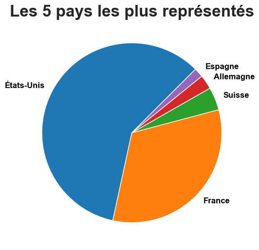

```python
plot_contributor_country(5)
```

#### Bilan

- **Variables écartées en raison du nombre de valeurs manquantes ou inutile pour notre application**
  - packaging : shape, material : matériaux utilisé pour l'emballage
  - packaging_tags : derscription de l'emballage
  - brands_tags : précision sur la marque
  - categories_tags : précision sur les catégories en anglais
  - origins : origins of ingredients
  - origins_tags : précision sur les origines des produits
  - manufacturing_places : places where manufactured or transformed
  - manufacturing_places_tags : précision sur les lieu de fabrication des produits
  - labels_tags : précision sur les labels
  - labels_fr : variable redondante avec labels
  - emb_codes : code lieu de fabrication
  - emb_codes_tags : emb_codes en Majuscule
  - first_packaging_code_geo : coordonnées du premier lieu d'emballage
  - cities : inutile 4 valeurs b,c,a
  - cities_tags : ville
  - purchase_places : Lieu de vente
  - stores : enseigne qui vend le produit
  - countries_tags : précision sur les countries
  - labels : peut nous donner des information important concernant l'idée d'app
  - categories : catégorie de produit
  - countries : list de pays ou le produit est vendu
- **Variables conservées**
  - **countries_fr** : pays
  - **brands** : marque du produit (meilleure syntaxe)
  - categories_fr : catégorie des produits : variable redondante avec categories

```python
# Colonne sélectionnées
col_tags = ['countries_fr','brands']
```

# 3.3 On explore les INGREDIENTS

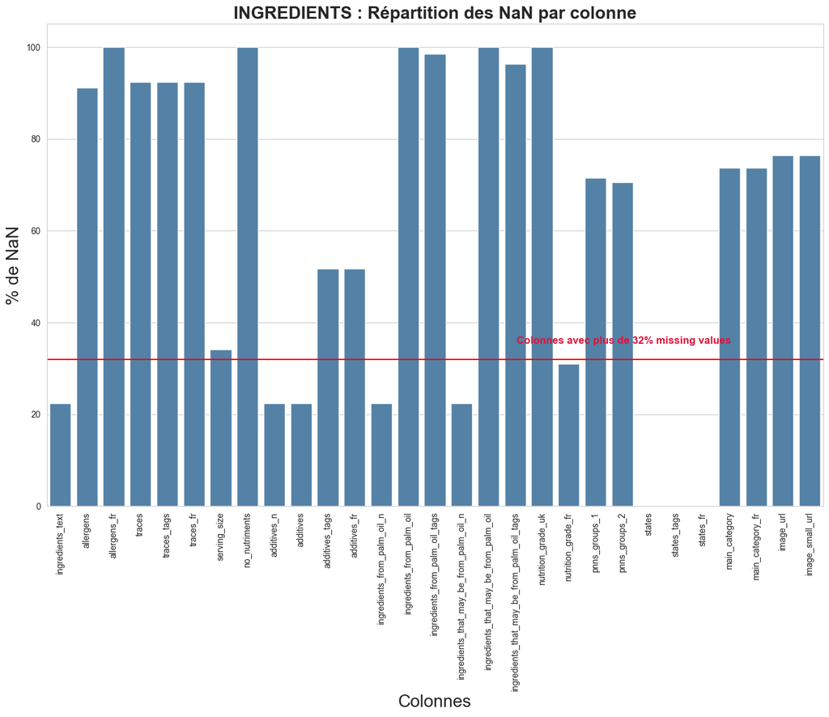

```python
tools.graph_NAN(data,32,34,63,"INGREDIENTS : Répartition des NaN par colonne")
```

```python
liste_ingredients = df.iloc[:,34:59].columns
info_list_colonnes(df,liste_ingredients,True)
```

```
________
Colonne : main_category_fr
Nombre de valeurs uniques : 3394
Type de la variable       : object
NaN                       : 71.76 %
Valeurs unique            : [nan 'Filet-de-boeuf' 'Légumes frais' ... 'Sauce-a-l-ail' 'Attieke'
 'pl:Szprot']

________
Colonne : image_url
Nombre de valeurs uniques : 66927
Type de la variable       : object
NaN                       : 76.31 %
Valeurs unique            : [nan
 'http://fr.openfoodfacts.org/images/products/000/000/002/4600/front.3.400.jpg'
 'http://fr.openfoodfacts.org/images/products/000/000/003/6252/front.4.400.jpg'
 ... 'http://fr.openfoodfacts.org/images/products/9918/front.3.400.jpg'
 'http://fr.openfoodfacts.org/images/products/993/501/000/0003/front.6.400.jpg'
 'http://fr.openfoodfacts.org/images/products/997/022/950/1521/front.3.400.jpg']

________
Colonne : image_small_url
Nombre de valeurs uniques : 66927
Type de la variable       : object
NaN                       : 76.31 %
Valeurs unique            : [nan
 'http://fr.openfoodfacts.org/images/products/000/000/002/4600/front.3.200.jpg'
 'http://fr.openfoodfacts.org/images/products/000/000/003/6252/front.4.200.jpg'
 ... 'http://fr.openfoodfacts.org/images/products/9918/front.3.200.jpg'
 'http://fr.openfoodfacts.org/images/products/993/501/000/0003/front.6.200.jpg'
 'http://fr.openfoodfacts.org/images/products/997/022/950/1521/front.3.200.jpg']

________
Colonne : energy_100g
Nombre de valeurs uniques : 3947
Type de la variable       : float64
NaN                       : 15.35 %
Valeurs unique            : [    nan 2243.   1941.   ... 4602.     76.1   448.59]

________
```

[output cut: 259 more lines]

```
NaN                       : 27.92 %
Valeurs unique            : [ nan  14.   0.  12.   7.  -6.  15.  11.   9.  16.  19.  -1.   6.  26.
  13.  10.  17.  22.  23.  30.   8.  25.   1.   2.  18.  21.  20.   3.
   4.  24.  27.  28.  -3.  -4.  -7.  -5.  -2.   5.  29.  31.  -8.  -9.
  35.  33.  32.  34. -10.  40.  37.  38. -11.  36. -13. -12. -14. -15.]

________
Colonne : nutrition-score-uk_100g
Nombre de valeurs uniques : 55
Type de la variable       : float64
NaN                       : 27.92 %
Valeurs unique            : [ nan  14.   0.  12.   7.  -6.  15.  11.   9.  16.  19.  -1.   6.  26.
  13.  10.  17.  22.  23.  30.   8.  25.   1.   2.  18.  21.  20.   3.
   4.  24.  27.  28.  -3.  -4.  -7.  -5.  -2.   5.  29.  31.  -8.  -9.
  35.  33.  32.  34. -10.  40.  37.  38. -11.  36. -13. -12. -14. -15.]
```